# 比亚迪发展史：从手机电池厂到全球新能源汽车第一

更新日期：2026年5月26日

2026年5月26日

更让人难以理解的是：在所有讲中国汽车崛起的故事里，比亚迪从来不是最被偏爱的那一个。它没有蔚来理想小鹏的”造车新势力”光环，没有华为问界的”互联网式营销”，没有奇瑞那种”22 年出口冠军”的史诗叙事。它只是非常老派地——做电池、做平台、做技术、做工厂——把每一个能自己做的零件都自己做了。

这份教程把比亚迪三十年拆开来讲。它的特别之处不在于”也卖了很多车”，而在于它做出了一种少见的公司：**一家以电池为根，向上长出整车、电控、电机、芯片、智驾，再向下长出矿、电池回收，最后把整条链都吃下来的公司**。理解这件事，可能比理解任何一款具体车型都更重要。

> **本教程会覆盖**：1995 王传福创业、2003 收购秦川造车、2008 巴菲特入股、2020 刀片电池、2022 停止燃油生产、DM-i 五代超级混动、e-Platform 3.0 与 CTB 一体化、易四方四电机平台、云辇智能车身、天神之眼智驾、2025 兆瓦闪充与 1000V 高压平台、王朝/海洋/腾势/仰望/方程豹五品牌矩阵、2024 年 427 万辆销量、海外四国四厂、以及把”垂直一体化”抽象成可迁移飞轮。

## 第1章 为什么应该认识比亚迪

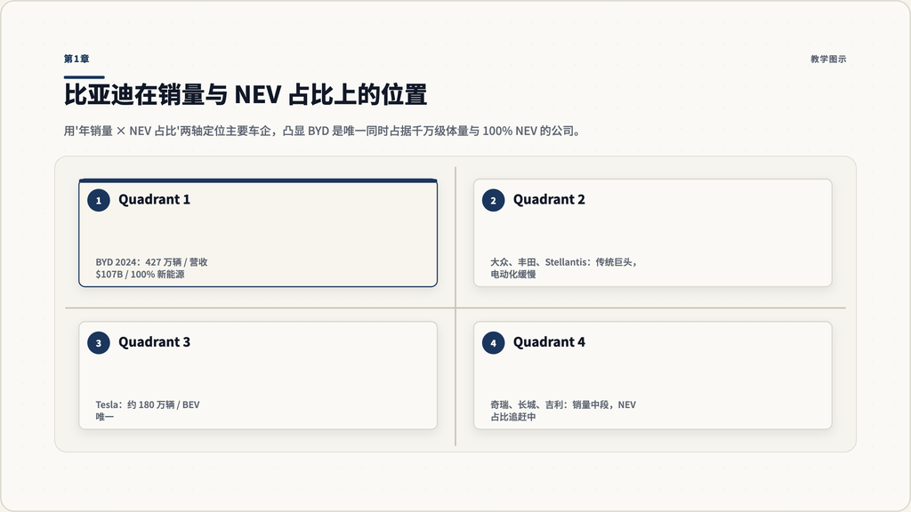

第1章：比亚迪在销量与 NEV 占比上的四象限位置

### 1.1 一个反常识的事实

这家公司是比亚迪。

如果你只关心一组数字，请记住：**2024 年比亚迪每卖出 5 辆车，就有 3 辆是插混、2 辆是纯电；没有一辆是纯燃油**。这件事在所有大型车企里独一份。

### 1.2 学习者常踩的认知坑

学习比亚迪时最容易掉进三个误区：

- **误区一：比亚迪 = 廉价电动车**。这个印象停留在 2010 年代。今天的比亚迪售价区间从 6 万元的海鸥到 168 万元的仰望 U9，跨度比任何一家中国车企都宽。
- **误区二：比亚迪是”特斯拉的中国版”**。两者底层逻辑相反——特斯拉是软件定义汽车，比亚迪是垂直一体化定义汽车。它们最终都做出了大量电动车，但路径完全不同。
- **误区三：比亚迪靠政府补贴**。新能源补贴在 2022 年底就完全退坡了。比亚迪 2023-2024 的爆发是在”无补贴时代”完成的。

把这三个误区拆掉，比亚迪才能被看清。

### 1.3 一张图理解比亚迪的位置

如果把主要车企画在”年销量 × NEV 占比”两个轴上：

- **大众、丰田、Stellantis**：年销量超千万级，但 NEV 占比 5-15%。
- **特斯拉**：年销量约 180 万辆，NEV 占比 100%。
- **奇瑞、长城、吉利**：年销量 100-300 万，NEV 占比 20-40%。
- **比亚迪**：年销量 427 万，NEV 占比 **100%**。

### 1.4 这一章你要带走的三件事

- 比亚迪不是”卖得便宜的特斯拉”，是一家完全不同物种的公司。
- 它在 2024 年用 100% NEV 阵容做到了 427 万辆销量，这是全球第一个。
- 后面的所有章节，本质上都在解释一句话：**它为什么能做到这件事**。

### 1.5 三问自检

不打开搜索，回答：

- 你能说出比亚迪在国内的两个销售网络叫什么名字吗？
- 你知道刀片电池跟普通 LFP 电池的差别在哪吗？
- 你听说过”易四方”、“云辇”、“天神之眼”吗？分别做什么？

如果三个都答不上来，说明你对比亚迪的印象停留在 2018 年之前。继续往下读。

## 第2章 电池起家（1995-2002）

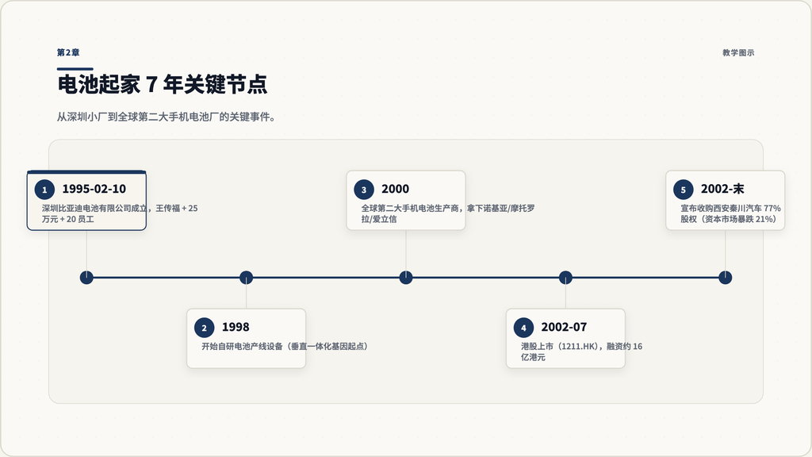

第2章：1995-2002 创业 7 年关键节点

### 2.1 一个被低估的起点：1995-02-10

比亚迪的官方成立日期是 1995 年 2 月 10 日，地点深圳。29 岁的创始人王传福用从表哥吕向阳那里借来的 25 万元人民币，租了一个深圳郊外的小厂房，雇了 20 名员工，开始做镍镉（NiCd）二次充电电池。

公司全名最初是”深圳比亚迪电池有限公司”——名字里只有”电池”两个字，没有”汽车”。

### 2.2 王传福这个人

要理解后面三十年的比亚迪，必须先理解王传福这个人：

- **学术背景**：中南工业大学冶金物理化学硕士，毕业后进入北京有色金属研究院，从研究员做到副主任，是中国电池电化学领域里最早一批”懂材料 + 懂工艺”的人。
- **判断力**：1990 年代中期，他注意到日本企业从镍镉转向镍氢和锂离子，留下了一个被全球忽略的”二级市场”——他选择从这个被抛弃的低端市场切入。
- **方法论**：他独创了”半自动化人海战术”——把日本工厂全自动化的高成本产线拆解成”人工 + 关键工序自动化”的混合模式，用中国当时的人力成本优势把电池价格直接打下来 30-50%。

王传福这个人后面贯穿整本教程。理解他用”半自动化人海战术”做电池，跟后面用”垂直一体化”做汽车，是同一个方法论的延续。

### 2.3 三大全球客户的”信任跳板”

比亚迪在 1990 年代后半段做到的最大事，是**拿下了诺基亚、摩托罗拉、爱立信三家国际客户的电池订单**。这件事的意义远比销量数字大：

- 它把比亚迪从”国内小厂”提升到”国际供应链合格供应商”。
- 它强迫比亚迪在质量、文档、流程上达到国际标准。
- 它给比亚迪带来稳定的现金流，让它有钱去试”不该试”的新业务。

到 2000 年，比亚迪已经成为全球第二大手机电池生产商；到 2002 年，它登陆港股上市（股票代码 1211.HK），融资约 16 亿港元。

### 2.4 一个少有人注意的伏笔

1998 年前后，比亚迪的电池产线开始尝试做一件别人没做的事：**自己做电池设备**。

国际同行的标准做法是从日本、德国买专用电池产线设备。比亚迪选择自己研发关键工序的设备——一方面是为了降成本，另一方面是因为王传福相信”设备自己做才能改设备，改设备才能改工艺”。

这个看起来很怪的选择，是比亚迪”垂直一体化”基因的最早表现。今天你看到比亚迪自己做芯片、做电控、做模具、做矿，都是 1998 年那个”自己造电池设备”决定的延伸。

### 2.5 这一章的关键认知

- 比亚迪的起点不是”造车工程师”，是”懂材料、懂工艺、懂成本的电池人”。
- 它的”半自动化人海战术”是后来”垂直一体化”的精神原型。
- 拿下国际大客户在 1995-2000 年间完成的能力建设，是后续所有跨界动作的底气。

### 2.6 把”半自动化人海”思路映射到你熟悉的行业

请写下你对一个传统行业的观察：

- 这个行业的国际龙头是怎么定义”标准产线”的？
- 有没有可能像比亚迪当年那样，把”全自动化”拆解成”半自动化 + 人海”？
- 这种重新定义如果发生，会给行业带来什么样的成本结构变化？

## 第3章 跨界造车（2003-2010）

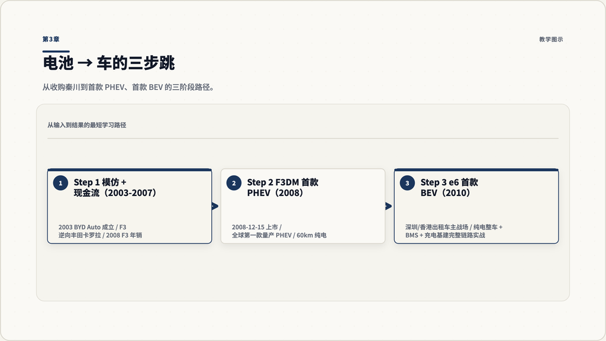

第3章：电池 → 车的三步跳

### 3.1 一个”反常识”的决定：电池厂收购车厂

2002 年底，王传福做了一个让公司管理层和资本市场都震惊的决定：**收购西安秦川汽车 77% 的股权**。

秦川汽车是陕西省国资委下属的小型汽车厂，主要产品是低端轿车 Flyer。秦川对比亚迪来说，**真正的价值不是车型、不是品牌，而是一张乘用车整车生产牌照**。

资本市场的第一反应是恐慌：比亚迪港股股价在收购宣布后两天内跌掉 21%。基金经理们的逻辑很简单：一家做电池的公司去做汽车，违反一切”专注”的常识。

王传福的逻辑也很简单：**电动汽车的核心是电池，比亚迪已经会做电池了；剩下的车身、底盘、电机、电控，无非都是机械零件，可以学**。如果他赌对了，比亚迪就提前 10 年抢到了新能源汽车的入场券。

### 3.2 三步跳：从电池到整车

2003-2010 这 8 年，比亚迪用”三步跳”完成了从电池到整车的转换：

- 2003 年成立比亚迪汽车有限公司，秦川厂房改造为乘用车产线。
- 2005 年推出 F3 轿车，外观、内饰、底盘几乎是丰田卡罗拉的逆向工程版。F3 售价不到卡罗拉一半（约 7-8 万元 vs 卡罗拉 13-15 万元）。
- F3 凭”看起来像合资车、价格只有一半”的策略迅速放量，2008 年销量突破 18 万辆，成为中国 A 级轿车销冠之一。

这个阶段的”逆向工程”在今天看是合规争议，但在当时它解决了一个核心问题：**让比亚迪汽车业务先活下来**。没有 F3 的现金流，就没有后面所有的故事。

**Step 2：F3DM——第一辆插混（2008）**

2008 年 12 月 15 日，比亚迪推出 F3DM——**全球第一款量产插电式混合动力轿车**。这辆车在技术上是个里程碑：

- 用比亚迪自己做的电池作为驱动主力。
- 用 1.0L 发动机作为增程辅助。
- 纯电续航 60 公里、综合续航超过 480 公里。

F3DM 销量并不大（前两年只卖了几百辆），但它给比亚迪带来一件无价的东西：**全球第一个量产 PHEV 的工程经验**。这套经验后来直接演化成 2021 年的 DM-i，把比亚迪推上插混冠军的位置。

**Step 3：e6——第一辆纯电（2010）**

2010 年比亚迪推出 e6 纯电出租车，主打深圳、香港的出租车市场。e6 在技术上还很粗糙，但它让比亚迪在”纯电整车 + 电池管理系统 + 充电基础设施”这条链上完成了最早的实战部署。

到 2010 年底，比亚迪汽车板块完成了从”我会做电池”到”我能做整车 + PHEV + BEV”的全面跳跃。

### 3.3 跨界的代价：2010-2012 的低谷

跨界不是没代价的。F3 的快速放量带来了三大隐藏问题：

- **品控漂移**：放量太快，老平台老工艺撑不住，2010 年 F3 售后投诉激增。
- **品牌固化**：“廉价合资替代品”的标签在国内消费者心里很难撕掉。
- **经销商动荡**：2010-2011 年比亚迪经历了大规模经销商裁撤与重组。

2011-2012 年，比亚迪汽车业务进入第一次重大低谷，年销量从 2010 年的 51 万辆掉到 2012 年的不到 45 万辆。这段时间里，王传福做了一个长期影响巨大的判断：**比亚迪要从”卖燃油车”转向”卖电动车”，哪怕这条路再难，也比继续靠 F3 维生有未来**。

这个判断在 2012-2018 年间让比亚迪付出了巨大代价，但也直接埋下了 2020 年之后爆发的种子。

### 3.4 这一章你要带走的三件事

- 跨界不是”勇气问题”，是”成本结构问题”——王传福收购秦川的真正目的是抢电动车整车牌照。
- 第一波放量靠 F3 的逆向工程，承认它，不洗白它。
- F3DM 是”全球第一款量产 PHEV”，这是后续 DM-i 王朝的起点。

### 3.5 行动锚点

挑一家你认为”主业稳定、不太可能跨界”的公司，回答：

- 它的”秦川时刻”会是什么样？需要收购什么样的资产？
- 如果它跨界，第一波现金流来自哪个产品？
- 它愿不愿意承担 5-8 年低谷？

## 第4章 巴菲特与新能源赌注（2008-2014）

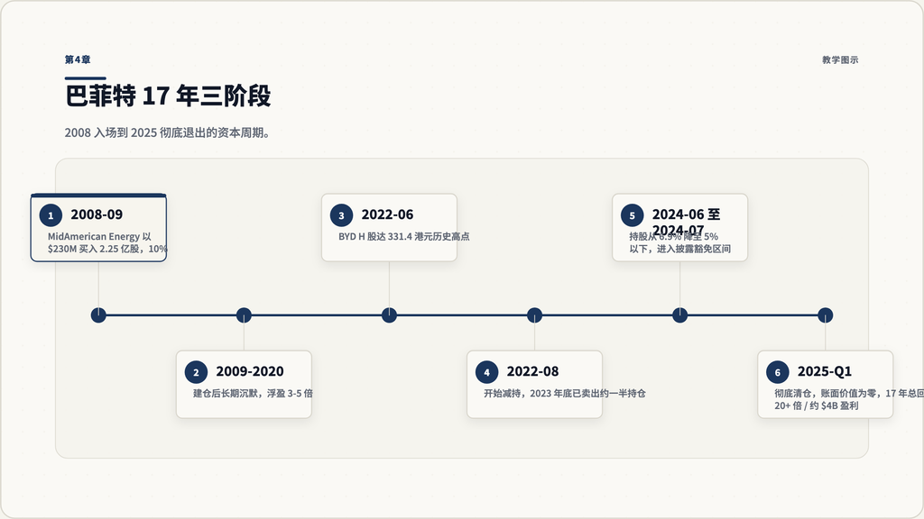

第4章：巴菲特 17 年三阶段

### 4.1 2008 年的一次”中国实验”

2008 年 9 月，雷曼倒下、全球资本市场最恐慌的那个月，伯克希尔哈撒韦下属的 MidAmerican Energy 宣布以约 2.3 亿美元买入比亚迪 2.25 亿股，**持股比例约 10%，每股价格约 1.02 美元**。

这是巴菲特个人投资历史上**少有的中国制造业押注**，也几乎是当时美国资本市场对中国新能源车的第一笔”严肃押注”。

促成这笔投资的关键人物是查理·芒格。芒格在拜访比亚迪后告诉巴菲特：“这家公司像爱迪生的实验室。”——这是芒格能给一家公司的最高赞美之一。

### 4.2 三阶段：17 年的完整投资周期

伯克希尔对比亚迪的持有总共持续了 17 年（2008-2025），可以分成三个阶段：

**阶段一：建仓与长期沉默（2008-2020）**

伯克希尔在 2008 年建仓后，12 年里几乎没有任何减持动作。这段时间里比亚迪经历了 F3 退潮、e6 试水、宋唐元秦四大王朝车型上线、F3DM 演化成 DM-i 等多次起伏。伯克希尔的浮盈在 2017-2019 年达到 3-5 倍。

**阶段二：刀片电池后的爆发与套现（2020-2023）**

2020 年刀片电池发布后，比亚迪 H 股股价从 50 港元附近一路飙升到 2022 年 6 月的历史高位 331.4 港元。伯克希尔从 2022 年 8 月开始陆续减持，到 2023 年底已经卖出约一半持仓。

**阶段三：彻底退出（2024-2025）**

- 2024-06：伯克希尔进一步减持，持股比例降至 6.9%。
- 2024-07：再次减持至 5% 以下，从此不再需要向香港交易所披露每一次卖出。
- **2025-Q1**：伯克希尔披露其能源子公司持有比亚迪的账面价值为零，意味着**已经彻底清仓**。
- 整个 17 年投资的最终总回报超过 20 倍，估算盈利约 40 亿美元。

### 4.3 为什么巴菲特会退出

很多人把退出解读成”巴菲特对比亚迪失去信心”。这是简化叙事，真实原因至少有三个：

- **伯克希尔的估值纪律**：2022 年比亚迪 PE 一度突破 200 倍，远超伯克希尔的常规持仓估值上限。
- **行业贝塔的变化**：中国新能源车赛道在 2023 年进入价格战，行业整体利润率下滑，巴菲特对”周期性产业”的警惕本来就高。
- **地缘风险**：2024-2025 中美关系反复紧张，伯克希尔出于风控考虑系统性减持中国资产。

**退出 ≠ 否定**。巴菲特公开多次表示比亚迪是”非凡的公司”。退出是估值和地缘逻辑，不是基本面逻辑。

### 4.4 这段投资史给学习者的启示

不要从”巴菲特看好/不看好”去判断一家公司。真实的资本博弈是：

- 早期入场需要”独立判断 + 长期承受波动”。
- 中期套现需要”估值纪律”。
- 退出需要”承认地缘 + 行业贝塔变化”。

巴菲特对比亚迪的 17 年持仓是经典案例，但**它不能替你判断今天该不该买比亚迪股票**。

### 4.5 自检

回答两个问题：

- 你能用一句话说清楚伯克希尔退出比亚迪的真实原因吗？
- 你身边有没有人因为巴菲特退出就把比亚迪看空？这个判断对吗？为什么？

## 第5章 刀片电池：2020 年的转折点

[figure not shown]

第5章：刀片 vs 传统 LFP 块 vs NMC 电池

### 5.1 一场没人预料到的反攻

2017-2019 年中国动力电池行业普遍认为”NMC（三元锂）才是未来”。原因很简单：能量密度高、续航长、是 BMW、奔驰、特斯拉这些高端品牌的首选。LFP（磷酸铁锂）被普遍认为”低端电池”，只适合公交车、出租车、低端 A00 级电动车。

2020 年 3 月，比亚迪发布刀片电池，**用 LFP 化学体系反过来打了 NMC**。这是中国动力电池行业过去十年里最戏剧性的一次反转。

### 5.2 刀片电池到底”刀片”在哪里？

刀片电池的核心创新不是化学，是**结构**：

- 电芯被做成 96 厘米长、9 厘米宽的扁长条状（像刀片）。
- 电池包内不再有传统的”电芯-模组-电池包”三层结构，而是把”刀片”直接排在电池包里，**取消模组层**。
- 这种结构让电池包的空间利用率提升 50% 以上。

结果是：**用同样的 LFP 化学，做出比传统 LFP 高 30-50% 能量密度的电池包**。把”LFP 能量密度低”这个最大短板补上了。

### 5.3 针刺试验：一次”破圈”的安全展示

2020 年 3 月，比亚迪通过一段公开测试视频做了一件公关史上的事——**用钢针穿刺刀片电池单体**：

- 刀片电池：表面温度 30-60℃，无烟、无火。
- 三元锂电池（NMC）：表面温度超过 500℃，剧烈燃烧。
- 传统块状 LFP：温度 200-400℃，虽然不剧烈燃烧但仍然不安全。

这段视频让”刀片电池 = 最安全的动力电池”在公众心智里牢牢扎根，这是比亚迪 2020-2023 销量爆发的心理学基础。

注意：针刺试验在工程界一直有争议（穿刺位置、穿刺速度、单体 vs 电池包等），但**作为公关和市场教育动作，它非常成功**。

### 5.4 第一辆装刀片电池的车：汉 EV（2020-06）

2020 年 6 月，比亚迪汉 EV 正式上市，成为**全球第一款搭载刀片电池的量产车**：

- 续航 605 公里。
- 售价 22.98-27.95 万元。
- 上市三个月月销破 1 万辆，半年破 4 万辆。

汉 EV 直接打开了比亚迪在 20 万元以上市场的局面，让”刀片电池 + B 级新能源轿车”成为 2020-2023 年中国电动车市场最重要的细分赛道。

### 5.5 刀片电池后面的连锁反应

刀片电池的真正价值不只是”卖了多少辆车”，是它触发了几个长期连锁反应：

- **CTB（电池车身一体化）**：刀片电池的扁长形状直接催生了”把电池包做成车身底板”的 CTB 技术，让车身扭转刚度提升 70%，空间又涨 25%。
- **LFP 全行业重新评估**：宁德时代、其他电池厂被迫跟进，宁德时代后来推出麒麟电池、CATL Shenxing 等都是对刀片的回应。
- **2022 全面切换**：到 2022 年中，比亚迪宣布**所有纯电车型全系标配刀片电池**，把它从”高端车专属”变成全系标准。

### 5.6 这一章你要带走的三件事

- 刀片电池真正的创新是结构（CTP），不是化学（LFP）。
- 针刺试验在工程上有争议、在公关上极其成功，要分开看。
- 刀片电池让比亚迪在 2020-2023 完成了”从国产替代到全球领跑”的心智切换。

### 5.7 找一个用结构创新打破材料瓶颈的案例

请尝试回答：

- 在你熟悉的另一个行业里（半导体、显示、医疗器械），有没有类似”用结构创新打破化学/材料瓶颈”的案例？
- 如果有，这种创新的可持续性如何？

## 第6章 DM-i 超级混动：1.0 到 5.0

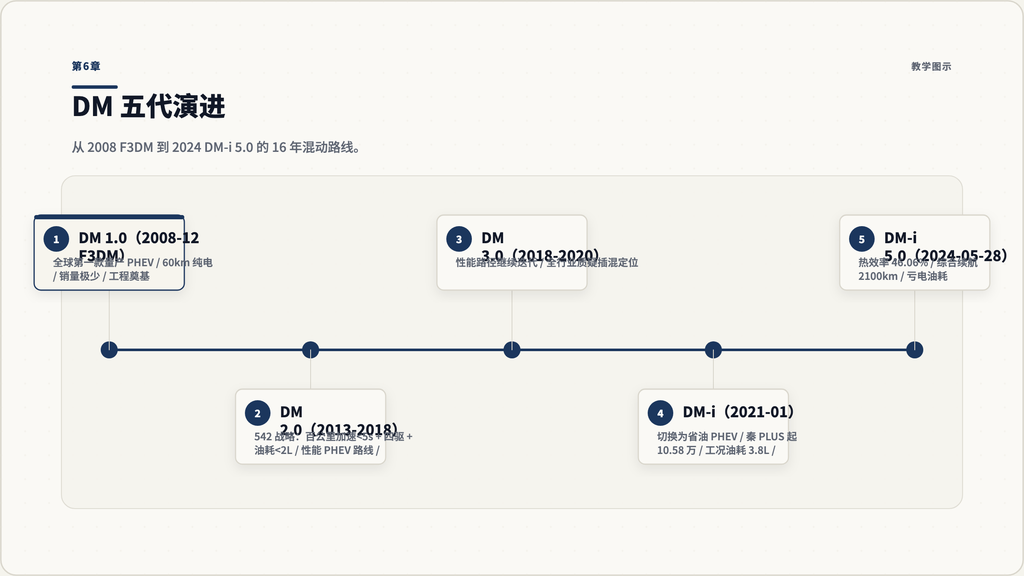

第6章：DM-i 五代演进时间线

### 6.1 把插混做成”主流答案”

2020 年之前，插电式混合动力（PHEV）在中国市场被认为是”过渡产品”——比纯电低端、比燃油高级、不三不四。2021 年比亚迪发布 DM-i 之后，这个认知被彻底改写。

到 2024 年，**比亚迪每卖出 5 辆车里有 3 辆是插混**——一个被认为”过渡”的技术，反而成了销量主力。

### 6.2 五代演进：从 F3DM 到 DM-i 5.0

**DM 1.0（2008，F3DM）**

第一款量产 PHEV，证明了技术路径可行，但销量极少。技术粗糙、油耗 + 电耗都不理想。

**DM 2.0（2013-2018，秦/唐 II 代）**

转向”性能 PHEV”路径：542 战略（百公里加速 < 5 秒、四驱、油耗 < 2L）。技术亮点是大功率电机 + 高性能。但市场反应一般，价格偏高、节油效果在使用工况下达不到宣传值。

**DM 3.0（2018-2020）**

继续在性能路径上迭代，但全行业开始质疑”插混到底是不是过渡技术”。

**DM-i（2021-1）**

这是比亚迪在 PHEV 路径上的一次根本切换：**从”性能 PHEV”转向”省油 PHEV”**。

- 核心理念：以电为主、油为辅；EHS 电混系统让发动机大部分时间在最高效率区间工作。
- 装车：秦 PLUS DM-i、宋 PLUS DM-i、唐 DM-i 三款车同步上市。
- 售价：秦 PLUS DM-i 起售 10.58 万元，比同级别合资燃油车便宜或持平。
- 工况油耗：3.8L/100km 级别。

DM-i 上市后，比亚迪插混销量从 2020 年的 5 万辆飙升到 2022 年的 95 万辆，**两年增长 18 倍**。

**DM-i 4.0（2022-2023）**

迭代版本，进一步优化油耗与电池管理，没有大版本更新。

**DM-i 5.0（2024-05-28）**

第五代 DM 是一次重大升级。首发车型 **秦 L DM-i + 海豹 06 DM-i**，关键数据：

- 发动机热效率 **46.06%**（量产汽油机的世界最高水平之一）。
- 综合续航 **2,100 公里**。
- 亏电油耗 **2.9L/100km**（2025-08 OTA 优化后降至 **2.6L/100km**，下降 10%）。
- 秦 L 起售 9.98 万元。

2024 年第三方直播测试中，海豹 06 实测亏电油耗低至 2.54L/100km。这意味着一辆中型轿车在没电状态下，**油耗已经低于绝大多数小型燃油车**。

### 6.3 DM-i 真正解决的不是技术问题，是消费者心理问题

DM-i 的销量爆发不是因为技术领先（技术早就有），而是因为它**精准击中了中国消费者最痛的两个点**：

- **里程焦虑**：纯电怕没电、燃油怕加油涨价；插混 + 2100 公里综合续航让两边都不焦虑。
- **使用成本**：用电时电费成本接近 0.1 元/公里，亏电时油耗也只有合资小车水平。

这两件事是过去十年中国家用车市场最大的两个”心理负债”。DM-i 把这两个负债同时清掉，所以销量爆发。

### 6.4 这一章你要带走的三件事

- DM-i 不是新技术，是”对的产品定位”。
- 第五代 DM-i 的 2.9L 油耗 + 2100 公里续航是行业里程碑级数字。
- 插混在中国市场已经从”过渡技术”变成”主流答案”，比亚迪是这一切换的主要推动者。

### 6.5 行动锚点

请挑出你认识的一类消费品（不一定是车），回答：

- 它有没有”被认为是过渡技术但其实是主流答案”的产品？
- 这种产品的爆发，是技术突破还是心理需求被精准击中？

## 第7章 e 平台与四大技术体系

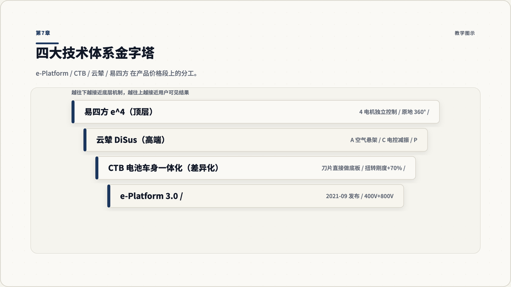

第7章：四大技术体系金字塔

### 7.1 把整车做成”乐高”

2018 年前后，比亚迪做了一件中国车企里少见的事——把整车开发从”一车一开”转向”平台化”。这件事的产物就是 e-Platform 系列。

理解 e-Platform 系列，是理解比亚迪今天技术体系的钥匙。

### 7.2 e-Platform 3.0（2021）：纯电模块化架构

e-Platform 3.0 在 2021 年 9 月发布，是比亚迪纯电整车架构的代表作。它解决了一件事：**让纯电车从”传统车的电动改造版”变成”为电动而生的新设计”**。

核心特征：

- 支持前驱、后驱、四驱多种驱动布局。
- 同时支持 400V 和 800V 两套电气架构。
- 标配 23,000 rpm 高速电机。
- 支持 CTB（Cell-to-Body）电池车身一体化技术。

第一批基于 e-Platform 3.0 的车型包括海豹（Seal）、海豚（Dolphin）、元 PLUS、海狮等。这套平台是比亚迪海洋系列爆发的工程底层。

### 7.3 CTB（Cell-to-Body）：电池就是底盘

CTB 是 e-Platform 3.0 上最值得单独讲的技术。它的核心创新是：

- 传统电池：电池包是装在车身底盘上的”零件”。
- CTB：电池包的上盖就是乘员舱的地板，**电池直接成为车身结构的一部分**。

结果是：

- 整车扭转刚度提升 70%（操控/碰撞安全大幅提升）。
- 乘员舱垂直空间增加 25%（同样轴距下后排腿部空间明显更大）。
- 整车重心更低，操控性更好。

CTB 是刀片电池长片结构 + e-Platform 3.0 整车架构两件事的合体结果。**没有刀片，没有 CTB；没有 CTB，e-Platform 3.0 没意义**。这是一个典型的”技术互锁”案例。

### 7.4 e-Platform 3.0 Evo（2024-05）：五大技术簇

2024 年 5 月，比亚迪发布 e-Platform 3.0 Evo（演进版），核心是**把平台从”模块化”升级到”智能化”**。Evo 引入了五大技术簇：

- 800V 高压平台普及到更多价格段。
- 智能扭矩矢量控制（vehicle dynamics）。
- 充电速度优化。
- 域控制器架构升级。
- 对智驾系统的硬件预留。

Evo 是 2025 年兆瓦闪充平台的前置铺垫。

### 7.5 易四方（e^4）：四电机独立控制

易四方是比亚迪 2023 年随仰望 U8 推出的另一套平台技术，核心是**给四个轮子各装一个独立电机，并实现毫秒级的扭矩独立控制**：

- 单轮反向旋转可以让 5 米长 SUV 原地 360 度旋转。
- 单轮爆胎时其他三轮的扭矩可以瞬间补偿，让车保持直线。
- 涉水时四个电机可以变成”船桨”驱动车浮渡水面（U8 著名的”水陆模式”）。

易四方对绝大多数消费者并不是”必需”，但它做出了两件事：

- 把”比亚迪能做最高端”这件事钉进了消费者心智。
- 沉淀了多电机独立控制的工程能力，未来会反哺主流车型。

### 7.6 云辇（DiSus）：智能车身控制

云辇是比亚迪 2023 年推出的智能车身控制系统，对标奔驰 ABC、宝马 M Adaptive。它包含四套子系统：

- **云辇-A**：空气悬架。
- **云辇-C**：电控减振。
- **云辇-P**：智能液压车身控制（仰望 U8 使用）。
- **云辇-Z**：全主动悬架（仰望 U9 使用）。

云辇让比亚迪在”操控/舒适”这个维度上第一次有了不靠合资学习也能拿出来的自主技术体系。

### 7.7 四大技术体系的金字塔位置

把四个体系画成一个金字塔：

- **底层（普及）**：e-Platform 3.0 / 3.0 Evo —— 服务王朝、海洋等主流车型。
- **中层（差异化）**：CTB —— 整合刀片电池与车身结构。
- **上层（高端）**：云辇 —— 服务腾势/方程豹/仰望。
- **顶层（极致）**：易四方 —— 服务仰望。

**这四个体系不是各自独立的，它们共享一套底层工程能力（电池、电机、电控），向上分化出不同的价格段产品**。这就是垂直一体化在产品端的具体表现。

### 7.8 这一章你要带走的三件事

- 不要把比亚迪当成”一辆车一辆车做”的公司，它是”一个平台一个平台做”的公司。
- CTB 是”刀片 + e-Platform 3.0”的化学反应，缺一不可。
- 易四方和云辇看起来豪华炫技，但工程能力的沉淀会反哺主流车型。

### 7.9 审视一家”产品多但平台少”的公司

挑一家你认为”产品多但平台少”的公司，回答：

- 它有没有自己的”e-Platform”？
- 如果没有，它的研发成本是怎么摊销的？
- 它未来 5 年最大的工程风险在哪？

## 第8章 兆瓦闪充与 1000V 平台（2025）

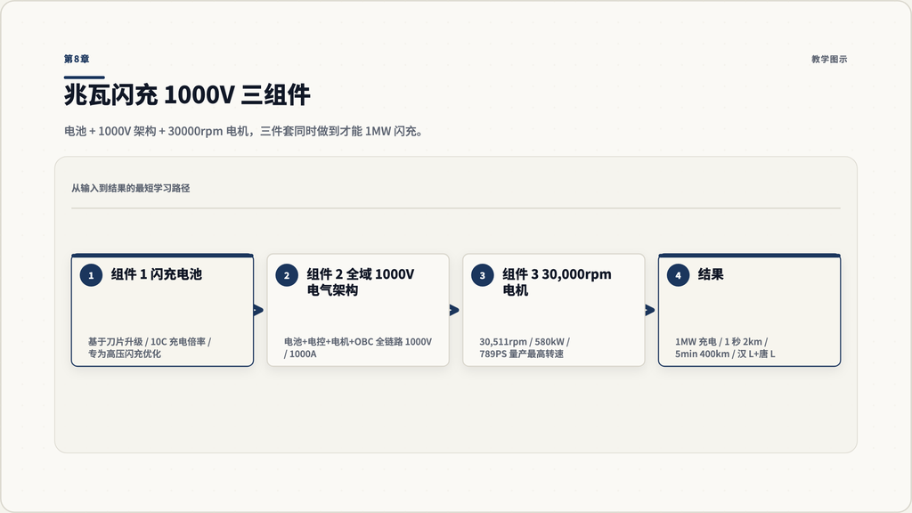

第8章：1000V 兆瓦闪充三组件

### 8.1 2025 年 3 月的”换桩日”

2025 年 3 月 17 日，比亚迪发布**全球首个量产的全域 1000V 高压平台**——超级 e 平台（Super e-Platform），同时发布**全球首座量产的 1 兆瓦（1000kW）闪充站**。

最直观的数字：**5 分钟充电，续航增加 400 公里**。这意味着电动车的补能时间，第一次真正接近燃油车的加油时间。

更具体的：**每秒钟充进 2 公里续航**。如果你站在充电桩边数 1、2、3、4、5——五秒钟，你的车已经多了 10 公里续航。

### 8.2 超级 e 平台到底新在哪

要做到 1 MW 充电，需要三件事同时做到：

- **电池**：能承受 10C 充电倍率而不大幅衰减。
- **电气架构**：整车系统电压从主流的 400V 直接拉到 1000V，电流也拉到 1000A。
- **电机**：旋转速度极限突破。

比亚迪在超级 e 平台上同时做到了这三件事：

- **闪充电池**：基于刀片电池升级，专为高倍率充电优化的化学和热管理。
- **全域 1000V 电气架构**：从电池、电控、电机、车载充电机全链路 1000V。
- **30,000 rpm 电机**：量产的最高转速电机，最高输出 580 kW / 789 PS。

这三件事单独做都很难，**同时做出来还能量产并装车，是 2025 年全球新能源汽车里的第一名**。

### 8.3 首批车型：汉 L + 唐 L

超级 e 平台首批车型是汉 L（中大型轿车）和唐 L（中大型 SUV），2025 年 4 月开始交付。两款车都开放了预订，定位在 20-30 万元价格段。

比亚迪的策略很清楚：**不把 1 MW 闪充做成只服务百万元级豪车的炫技，而是做成 20-30 万元主流家用车的标配**。这跟特斯拉的”高端先发、慢慢下沉”逻辑完全相反。

### 8.4 4000 + 充电桩的全国铺设

兆瓦闪充的最大问题不是车，是桩。一辆能充 1 MW 的车没有 1 MW 的桩就只能当普通快充用。比亚迪给出的答案是：

- 首批 500 座 1 MW 闪充站在 2025 年 4 月跟汉 L、唐 L 同步上线。
- 2025-2026 年全国规划建设 4,000+ 座 1 MW 闪充站。

这件事意味着：**比亚迪不仅做了车，还自建充电网络**。这是垂直一体化在能源补给端的延伸。

### 8.5 这次发布的真正意义

超级 e 平台不只是一个产品发布，它有两层更长期的含义：

- **第一层：补能焦虑终结**。当 5 分钟能补 400 公里，电动车的最后一块”心理负债”被还清。这件事的市场影响在 2025-2027 才会全面显现。
- **第二层：技术世代切换**。1000V 是未来 5-10 年的纯电整车架构标准，比亚迪率先量产意味着它在这一波技术世代里跑在前面。下一个跟上的会是宁德时代、华为、小米等。

### 8.6 这一章你要带走的三件事

- 1 MW 闪充 = 电池 + 1000V 架构 + 30000 rpm 电机三件套，缺一不可。
- 比亚迪把这套技术下沉到 20-30 万元价格段，而不是只服务豪车。
- 桩自己建，能源补给链被纳入垂直一体化。

### 8.7 行动锚点

请尝试预测：

- 如果 1 MW 闪充在 2027 年成为新能源车标配，整个加油站行业会发生什么？
- 你认识的某家加油站连锁，会怎么应对？

## 第9章 王朝 + 海洋：双网双品牌

[figure not shown]

第9章：王朝 vs 海洋

### 9.1 同一家公司，两套销售网络

2021 年之前，比亚迪的销售只有一套网络。2021 年开始，比亚迪做了一件中国车企里少见的事——**把同一家公司的车型分成两个独立销售网络**：

- **王朝网（Dynasty Network）**：销售秦、汉、唐、宋、元等”王朝系列”车型。
- **海洋网（Ocean Network）**：销售海豚、海豹、海鸥、海狮等”海洋系列”车型。

每一家经销商只能加盟其中一个网络，不能两边都做。两套网络的展厅设计、广告调性、销售话术都是独立的。

### 9.2 为什么要这么做

把销售网络拆成两套有三个目的：

- **覆盖更宽的消费者**：王朝偏稳重、中年家庭；海洋偏年轻、城市单身/年轻家庭。同一时期同一价格段可以同时打两个心智。
- **提高经销商收益**：让每个经销商专注一组车型，单店利润反而比”全卖”高。
- **试错与赛马**：两个网络之间有竞争，激励经销商加大投入。

这个策略在 2022-2024 年带来了销量的快速放量。**很多人以为比亚迪销量爆发是因为新车多，其实更核心的原因是渠道扩了一倍**。

### 9.3 两套体系的车型分工

| 系列 | 王朝（Dynasty） | 海洋（Ocean） |
| --- | --- | --- |
| 旗舰轿车 | 汉 EV / 汉 DM-i | 海豹 / 海豹 06 DM-i |
| 主力 SUV | 唐 / 宋 PLUS / 元 PLUS | 海狮 07 / 海狮 06 |
| 入门轿车 | 秦 PLUS / 秦 L | 海豚 / 海鸥 |
| 命名风格 | 中国朝代名 | 海洋动物名 |
| 主导用户 | 稳重家庭、商务 | 年轻人、城市代步 |

注意一个细节：**秦 L DM-i 和海豹 06 DM-i 在工程上几乎是同一辆车（共平台、共动力、尺寸接近），只是外观调性和销售网络不同**。这是双网策略最赤裸的一次体现——一辆车两个壳子两套渠道。

### 9.4 这种策略可复用的边界

双网策略不是适用所有公司：

- 适用：产品线宽、价格段交叠多、渠道是关键瓶颈。
- 不适用：单一旗舰产品、品牌叙事高度集中、渠道数量已经过剩。

比亚迪能这么干，前提是**车型数量足够多 + 经销商利润空间足够厚**。中小品牌强行复制双网，往往会把自己拖死。

### 9.5 这一章你要带走的三件事

- 比亚迪销量爆发不仅是技术红利，也是渠道翻倍红利。
- 王朝和海洋分别承担不同消费者心智。
- 双网策略需要产品多、渠道厚、品牌包容力强，不能盲目复制。

### 9.6 给一个国产品牌画双网

挑你熟悉的一家国产品牌，回答：

- 它如果分双网，会怎么分？
- 它的经销商利润够不够支撑两套体系？

## 第10章 高端三品牌：腾势 / 仰望 / 方程豹

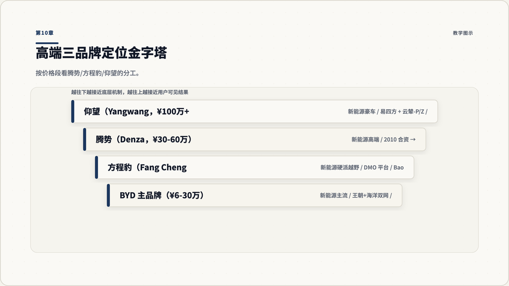

第10章：高端三品牌定位金字塔

### 10.1 一家”廉价电动车”公司为什么要做三个高端品牌？

第 1 章提到一个误区：“比亚迪 = 廉价电动车”。这个印象的主要原因是 F3 时代的低端定位太深入人心。

2023-2024 年，比亚迪用一次性推出三个高端品牌的方式，强行扭转了这个心智：

- **腾势（Denza）**：30-60 万元价格段，新能源高端。
- **方程豹（Fang Cheng Bao）**：30-80 万元价格段，新能源越野。
- **仰望（Yangwang）**：100 万元以上，新能源豪车。

三个品牌不是同时启动的，它们有自己的诞生背景。

### 10.2 腾势：从合资到全资

腾势的历史最长，也最戏剧：

- **2010-05**：比亚迪与戴姆勒 50:50 合资成立腾势，注册资本约 7.76 亿元。
- **2014-末**：第一款车 Denza EV 上市，但销量惨淡。**2010-2021 年合资 11 年累计销量仅约 2.3 万辆**。
- **2021-12**：合资重组，戴姆勒持股降到 10%，比亚迪持有 90%。
- **2022-2023**：腾势 D9 MPV 上市，凭借”大空间 + 高端商务”定位月销破 1 万辆，腾势第一次真正赚钱。
- **2024-07**：戴姆勒把最后 10% 卖给比亚迪，**腾势变成 BYD 100% 控股**。
- **2024-09-20**：腾势 Z9GT 上市，价格 33.48-41.48 万元，纯电版本续航 1036 公里，成为当时全球量产纯电续航最长车型之一。
- **后续**：截至 2024 年底腾势累计销量超 20 万辆，远超合资 11 年的总和。

腾势是教科书级的合资案例：**合资学习 + 重组接管 + 自主放量**，三步走完整执行。

### 10.3 仰望：百万级豪车的”硬碰硬”

仰望（Yangwang）2023 年 1 月发布，是比亚迪历史上第一次正面挑战 BBA 和保时捷的高端品牌：

- **U8（2023-04-18 上市）**：硬派 PHEV 越野 SUV，售价约 109.8 万元起。搭载易四方四电机平台和云辇-P 液压车身控制系统，著名的”水陆模式”让 SUV 可以浮渡水面。
- **U9（2024-02-25 上市）**：纯电超跑，售价 168 万元 / 约 23.35 万美元。四电机总功率 960 kW、1306 马力、0-100 km/h 2.36 秒、最高时速 309 km/h。搭载云辇-Z 全主动悬架，是比亚迪技术能力的”上限展示”。
- **U7（2025-01 上市）**：百万级新能源旗舰轿车。
- **2026-03-05**：仰望 U7、U8、U8L 三款车型同步上市/升级，U9 Xtreme 特别版亮相 2026 北京车展。

仰望最重要的不是销量（百万级车型本来就量小），是**它让”比亚迪能做最高级”在公众心智里成立了**。这件事的市场价值远超百万级车型本身的销量。

### 10.4 方程豹：新能源硬派越野

方程豹（Fang Cheng Bao）2023 年 6 月 9 日品牌发布，定位是 30-80 万元价格段的新能源硬派越野：

- **Bao 5（2023-08-16 发布，2023-11 交付）**：中型 PHEV 硬派 SUV，基于专属的 DMO（Dual Mode Off-road）平台。
- **Bao 8（2024-11-12 上市）**：中大型 PHEV 硬派 SUV，售价 37.98-40.78 万元。三个月内累计交付破 1 万辆，刷新硬派越野品类的交付速度纪录。
- **Bao 3、Bao 9 等后续车型陆续推出**。

方程豹精准切入了一个传统燃油车主导的领域（硬派越野，长期被丰田陆巡、奔驰 G、坦克 300 等占据），用新能源动力 + 较低价格做差异化。

### 10.5 三品牌的金字塔位置

如果按价格从下往上画：

```
仰望（Yangwang）         ¥100万+    新能源豪车
腾势（Denza）            ¥30-60万   新能源高端
方程豹（Fang Cheng Bao） ¥30-80万   新能源硬派越野
[主品牌 BYD]             ¥6-30万    新能源主流
```

三个高端品牌共用比亚迪底层技术（电池、电机、电控、智驾），但用完全独立的品牌叙事和销售网络。

### 10.6 这一章你要带走的三件事

- 高端品牌不是用来快速赚钱的，是用来抬升主品牌心智的。
- 腾势是”合资学习 → 重组接管 → 自主放量”教科书案例。
- 仰望让”BYD 能做最高级”这件事在公众心智里成立。

### 10.7 给一个低端固化品牌设计高端突围

挑一个在国内被认为”低端定位很难翻身”的品牌，回答：

- 它最缺的不是产品，是高端心智吗？
- 它能不能借鉴比亚迪的”同时推三个高端品牌”打法？

## 第11章 2024 年的四个里程碑

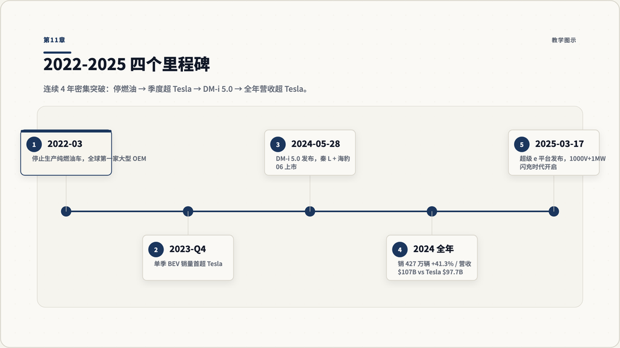

第11章：2022-2025 四件大事

### 11.1 一年里发生四件大事

把这四件事放在一起看，本质上是同一句话：**比亚迪在 2024 年完成了从”中国新能源销冠”到”全球新能源销冠”的身份切换**。

### 11.2 但是——一个必须澄清的细节

2024 年比亚迪和特斯拉的”全球第一”之争存在一个关键细节：

- **按 BEV 交付**：特斯拉全年 1,789,226 辆 vs 比亚迪 BEV 1,764,992 辆，特斯拉以约 2.4 万辆的微小差距保住了 BEV 交付全球第一。
- **按 BEV 生产**：比亚迪 1,777,965 辆 vs 特斯拉 1,773,443 辆，**比亚迪以约 4,500 辆的微小差距超过特斯拉**。
- **按总新能源车（BEV + PHEV）销量**：比亚迪 4,272,145 辆 vs 特斯拉 1,789,226 辆，**比亚迪绝对领先**。

所以严格说，2024 年是这样的：**比亚迪在生产端和总销量端超过特斯拉；特斯拉仍保住了 BEV 交付的最后冠军**。

诚实承认这个细节，比简单说”比亚迪打败特斯拉”重要。

### 11.3 时间轴：四件事在哪一年发生

把四个里程碑展开放在 2022-2025 的时间轴上：

- **2022-03**：停止生产纯燃油车，**全球第一家这么做的大型车企**。
- **2023-Q4**：BEV 季度销量首次超过特斯拉，成为单季全球 BEV 销冠。
- **2024-05-28**：DM-i 5.0 发布，秦 L + 海豹 06 上市。
- **2024-07**：腾势 100% 控股完成。
- **2024-09-20**：腾势 Z9GT 上市。
- **2024-11-12**：方程豹 Bao 8 上市。
- **2024 全年**：销量 427 万 / 营收 1077 亿美元。
- **2025-03-17**：超级 e 平台发布（1000V + 1 MW 闪充）。

### 11.4 这一章你要带走的三件事

- 2024 年比亚迪完成了”全球新能源销冠”的实质切换。
- 严格区分 BEV 交付 vs BEV 生产 vs 总新能源销量，三个口径下结论不同。
- 2022-2025 是连续四年的”高密度突破期”，不是 2024 一年的偶然。

### 11.5 自检

如果有人问你”2024 年比亚迪打败特斯拉了吗”，请用三句话回答：

- 在哪个口径下打败了？
- 在哪个口径下还差一点？
- 这件事的真正意义是什么？

## 第12章 海外扩张：4 国 4 厂

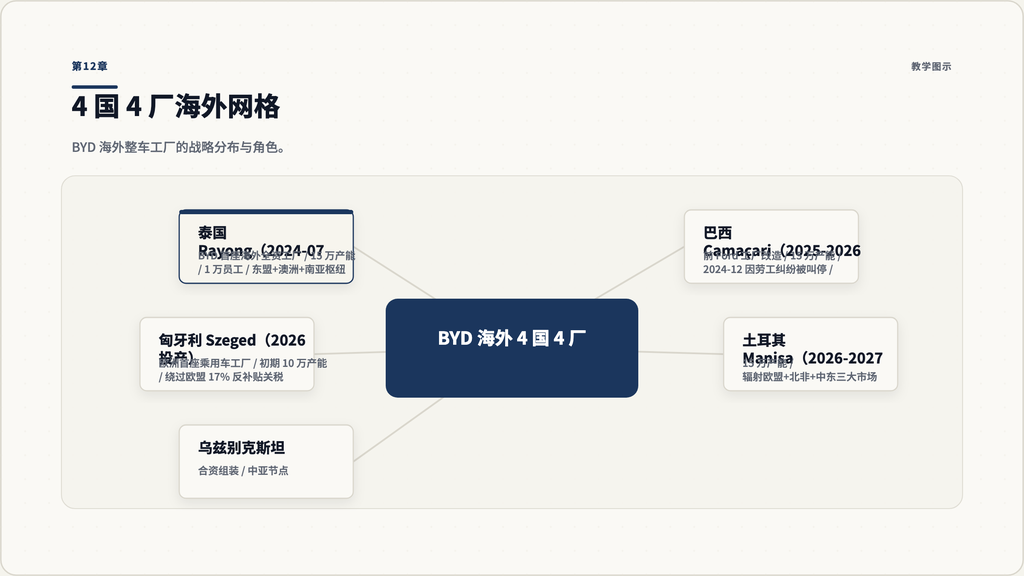

第12章：比亚迪海外四国工厂分布

### 12.1 比亚迪的海外打法和奇瑞完全不同

- **奇瑞**：海外副品牌优先（Omoda / Jaecoo），10+ 海外工厂网格化分布，从中东、南美、东南亚到欧洲。
- **比亚迪**：主品牌 BYD 全球统一使用，4 个海外整车工厂集中在战略要地（泰国 / 巴西 / 匈牙利 / 土耳其）。

两家走的不是同一条路。**奇瑞是”广撒网 + 副品牌切割”，比亚迪是”重点突破 + 主品牌输出”**。

### 12.2 四国四厂的具体情况

**泰国罗勇（Rayong）**

- 2024-07 投产。
- 规划年产能 15 万辆。
- **比亚迪第一座海外全资工厂**。
- 预计雇佣 1 万名当地工人。
- 主要服务东盟 + 澳大利亚 + 南亚市场。

**巴西卡马萨里（Camaçari）**

- 收购前福特工厂改造，规划年产能 15 万辆。
- 预计 2025-2026 年陆续投产。
- **2024 年圣诞节前工厂建设因劳工纠纷被巴西劳动部叫停**——这是比亚迪海外扩张中第一次重大公共危机。
- 主要服务南美市场。

**匈牙利赛格德（Szeged）**

- **比亚迪在欧洲的第一座乘用车工厂**。
- 2026 年开始投产，初期年产能约 10 万辆。
- 战略意义：绕过欧盟对中国整车的反补贴关税，直接在欧盟境内生产。

**土耳其马尼萨（Manisa）**

- 规划年产能 15 万辆，2026-2027 投产。
- 战略意义：覆盖欧盟、北非、中东三个市场的辐射节点。

另外比亚迪在乌兹别克斯坦还有合资组装工厂。

### 12.3 两个目标：2030 年海外销量占 50%

比亚迪在 2024-2025 年公开宣布过两个目标：

- **2025 年全年海外销量**：突破 100 万辆（2024 年是 41.7 万辆，2025 年前 11 个月已突破 90 万辆，全年破百万几乎已成定局）。
- **2030 年海外销量占比**：占集团总销量 **50%**。

这两个目标加在一起，意味着比亚迪未来 5 年的增长几乎全部要靠海外。这是为什么 4 国 4 厂同时启动。

### 12.4 中欧关税摩擦下的”匈牙利赌注”

2024 年欧盟对中国电动车征收 17.4%-38.1% 的反补贴关税，比亚迪被加征 17%。**这是比亚迪在欧洲面临的最大政策风险**。

匈牙利工厂的战略价值就在这里：一旦工厂正式投产，**车型变成”欧盟制造”，关税彻底归零**。

比亚迪的算法很清楚：欧盟关税短期吃利润，但 18-24 个月后匈牙利工厂量产，关税问题永久解决。这是一次”用时间换空间”的赌注。

### 12.5 这一章你要带走的三件事

- 比亚迪的海外打法和奇瑞不同：重点突破，主品牌输出。
- 4 国 4 厂分别承担不同战略角色：泰国是东盟枢纽、巴西是南美本地化、匈牙利是欧盟规避关税、土耳其是欧+中东+北非辐射点。
- 2030 年海外销量占 50% 是比亚迪未来 5 年的核心增长来源。

### 12.6 行动锚点

请挑一家正在准备出海的中国制造业公司，回答：

- 它的打法更像奇瑞还是更像比亚迪？为什么？
- 如果它要选第一座海外工厂，应该建在哪？关税、辐射、还是技术升级？

## 第13章 智能驾驶平权：天神之眼

[figure not shown]

第13章：传统智驾 vs 天神之眼全系下沉

### 13.1 一个让全行业被迫跟进的动作

2025 年 2 月，比亚迪宣布一件让全行业头痛的事：**把高阶智能驾驶系统”天神之眼”（God’s Eye）作为标准配置全系下放，不加价**。

这件事的冲击力在于：在 2025 年之前，高阶智驾（高速 NOA / 城市 NOA / 自动泊车）几乎只装在 30 万元以上的车上。比亚迪一句话把它装到了**起售 6.98 万元的海鸥**上。

### 13.2 三档体系：A / B / C

天神之眼分成三档，对应不同档位的车型：

- **天神之眼 A**：搭载 3 个激光雷达 + DiPilot 600 系统（600 TOPS 算力）。装在仰望系列豪华车上。
- **天神之眼 B**：搭载 1 个激光雷达 + DiPilot 300 系统（300 TOPS 算力）。装在腾势和部分旗舰车上。
- **天神之眼 C**：无激光雷达，纯视觉方案，DiPilot 100 系统（100 TOPS 算力）。**配备 12 个摄像头 + 5 个毫米波雷达 + 12 个超声波雷达**。装在 7-20 万元价格段的主流车型上，包括海鸥、海豚、秦 L 等 21 款车。

### 13.3 这件事真正改变了什么

智驾平权动作的真正影响在三个层面：

- **行业层面**：竞争对手被迫跟进。如果同价位友商不能匹配类似配置，立刻在产品力上吃亏。结果就是整个 2025 年中国新能源市场的”智驾军备竞赛”。
- **消费者层面**：用户对”什么车应该有智驾”的预期被永久改写。10 万元车没智驾会变成”残缺”。
- **数据层面**：截至 2025 年 11 月，**比亚迪已经有超过 230 万辆 God’s Eye 装车上路**，单月新增超过 31 万辆。这给比亚迪带来海量真实驾驶数据，加速算法训练。

### 13.4 这是垂直一体化的最后一块拼图

如果把比亚迪的垂直一体化看作一个系统，2025 年之前还缺一个核心组件——智能驾驶。天神之眼把这块补上了。

- 电池：自己做（刀片）。
- 电机：自己做（30000 rpm）。
- 电控：自己做（DiPilot 域控制器）。
- 智驾：自己做（God’s Eye）。
- 整车：自己做（多平台多品牌）。
- 渠道：自己做（王朝 + 海洋 + 三高端）。
- 充电网络：自己做（4000+ 兆瓦闪充站）。

**没有一家全球车企在 2026 年同时拥有这一整套链路**。

### 13.5 智驾平权的代价

不能只讲优势：

- 全系下放智驾对算力、传感器、软件团队的要求极高，研发成本巨大。
- 100 TOPS 的方案在算力上低于头部竞品（华为 ADS 3.0 在 500 TOPS+ 级别），实际体验仍有差距。
- 一旦发生安全事故，舆论负担会比”高端车智驾出事”更大，因为用户基数和保有量都更大。

### 13.6 这一章你要带走的三件事

- 智驾平权不是”善意”，是”竞争武器”——它强迫整个行业跟进。
- 三档体系（A / B / C）让比亚迪同时覆盖豪车与平价车。
- 智驾是垂直一体化的最后一块拼图，它把比亚迪从”做车的公司”变成”做完整智能电动车系统的公司”。

### 13.7 自检

请回答：

- 你最近一次买车（或考虑买车）时，智驾的优先级在你心目中是第几位？
- 如果 8 万元的车都有智驾了，你愿不愿意为”更好的智驾”多付 5 万元？

## 第14章 BYD 模型对中国出海的可迁移启示

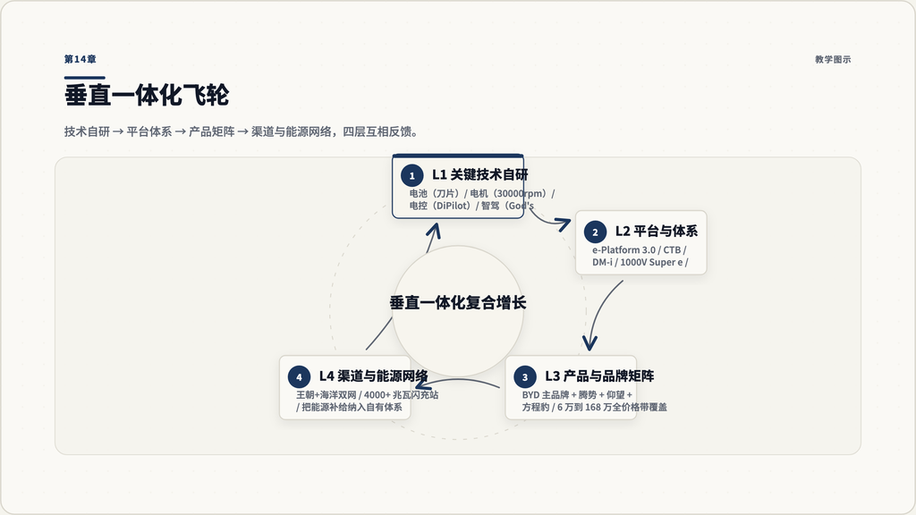

第14章：垂直一体化飞轮

### 14.1 把比亚迪 30 年抽象成一个模型

最后一章，把所有内容压成一个可以应用到其他公司的可迁移模型。我把它叫做**垂直一体化飞轮**：

- **L1 — 关键技术自研**：电池、电机、电控、智驾、芯片，所有真正决定性能的零件自己做。
- **L2 — 平台与体系**：把单独的技术合成平台（e-Platform / CTB / DM-i / God’s Eye），让一项技术能服务多款产品。
- **L3 — 产品与品牌矩阵**：用同一套平台向上向下分化出主品牌 + 三高端品牌，覆盖 6 万到 168 万元的整条价格带。
- **L4 — 渠道与能源网络**：双网（王朝 + 海洋） + 4000+ 闪充站，把渠道和能源补给纳入自己的体系。

四层不是阶梯，而是同时旋转的飞轮：

- L1 给 L2 提供能力。
- L2 让 L3 可以低成本扩张产品线。
- L3 让 L4 有足够 SKU 支撑双网渠道。
- L4 反过来给 L1 提供市场反馈和现金流。

**当四层互相反馈时，公司就进入了真正的”垂直一体化复合增长”阶段**。这是比亚迪 2020-2026 年爆发的本质。

### 14.2 把四层飞轮变成 checklist

如果你管理一家正在做技术驱动型业务的中国制造业公司：

**L1：关键技术自研**

- 你的产品里 80% 的成本来自哪几个零件？
- 这几个零件你能不能自己做？
- 不能做的关键零件，你有没有”5 年内自研”的计划？

**L2：平台与体系**

- 你的产品是”一个一个开发”还是”基于平台衍生”？
- 你的研发成本能不能被多个产品摊销？
- 你的平台敢不敢同时支持 6 万元和 168 万元的产品？

**L3：产品与品牌矩阵**

- 你有没有覆盖从入门到旗舰的完整价格段？
- 你的高端品牌是”另立门户”还是”主品牌延伸”？
- 你的高端品牌愿不愿意承担”5 年不赚钱”？

**L4：渠道与能源/服务网络**

- 你的渠道是经销商主导还是自己主导？
- 你的售后/补给/服务体系是自有还是依赖第三方？
- 当行业格局变化时，你的网络能不能快速调整？

### 14.3 比亚迪不能 100% 复制的部分

诚实地说，比亚迪模式有一部分是不可复制的：

- 它的电池起家身份（“我懂电池”是绝大多数车企没有的禀赋）。
- 它的”半自动化人海战术”吃了 1990-2010 年的中国人力成本红利，今天复制不了。
- 它和巴菲特的 17 年长期资本关系给了它穿越周期的耐心，这是一次性历史机遇。

但**垂直一体化飞轮的结构本身可以被任何制造业公司复用**。它要求的不是天才创始人，是耐心、纪律和”把成本拆到零件层”的工程文化。

### 14.4 把这门课收尾

比亚迪 1995-2026 这 31 年，本质上是一家中国制造业公司从”做手机电池”走向”做完整智能电动车系统”的极端样本：

- 它跨界过一次（电池到车），但只跨了一次。
- 它经历过 F3 时代的质量塌陷和 2010 年的品牌固化。
- 它在 2018-2019 年差点被市场抛弃。
- 但它在 2020-2024 年间用刀片电池、DM-i、平台体系、品牌矩阵、智驾平权五张牌连续打出了爆发。

把这件事看清楚，对所有想做”硬科技 + 制造业”的中国公司都是一面镜子：**真正的护城河不是某一项技术，是把一条链上每一个零件都自己做的耐心**。

### 14.5 最后的练习

请用 500-800 字写一份给自己（或你跟踪的公司）的”四层飞轮自检报告”：

- 你在哪一层最强？
- 哪一层最弱？
- 如果只能在一层投入更多资源，应该投哪一层？为什么？

写完之后保存好，6 个月后再回来看一次。

## 第15章 BYD 在加拿大：市场前景与进入策略

[figure not shown]

第15章：BYD 进入加拿大三条路径对照

### 15.1 为什么单独讲加拿大

加拿大是一个被中国出海讨论严重低估的市场。1 亿美元规模的中国汽车出海稿件里，谈欧洲、东南亚、巴西、中东都有人写，但**专门讲加拿大的几乎没有**。原因有两个：

- 加拿大体量小：年销量约 180 万辆，只有美国的 1/10。
- 加拿大政策跟随美国：很多人默认”美国怎么定关税，加拿大就怎么定”。

但这两点本身就是机会。**正因为没人写，正因为政策跟随节奏比美国慢半步，加拿大反而是中国 EV 进入北美的”试错窗口”**。BYD 已经在做的事，证明它把这个窗口看清楚了。

### 15.2 关税的两次切换：从 100% 到 6.1%（quota 内）

理解 BYD 在加拿大的处境，要先理解关税政策的两次切换：

**第一次切换：2024-10-01**

加拿大政府对所有中国产电动车（含 PHEV）加征 **100% 关税**，在原有最惠国 6.1% 关税的基础上叠加，**实际综合税率约 106.1%**。这一动作几乎照抄了美国 2024-05 同样的 100% 关税政策。

覆盖范围：乘用车、卡车、巴士、配送车全部纳入。

这次切换的直接效果：中国 EV 在加拿大的整车进口实质上被冻结。包括 Tesla 上海工厂生产的 Model 3/Y 也一度受影响（后来 Tesla 切换为美国和德国产）。

**第二次切换：2026-01**

加拿大宣布启动”**tariff quota（关税配额）**”机制：

- 每年允许最多 **49,000 辆中国产 EV 按 6.1% 关税进口**。
- 超出配额部分继续按 100% 税率。
- 这是中加关税自 2024 年后第一次实质性松动。

这个 4.9 万辆/年的配额在加拿大 EV 总量里大约相当于 **15-20% 的份额空间**。一旦被中国品牌实际抢光，加拿大 EV 市场格局会被显著重塑。

### 15.3 BYD 在加拿大的”隐藏起跑”

BYD 在加拿大做了一件几乎所有竞争对手都不知道的事——**早在加征关税之前就完成了所有合规备案**。具体来说：

- **Transport Canada Appendix G 注册**：BYD 已经在加拿大运输部”乘用车进口认证厂商”清单里。这意味着 BYD 不需要再走逐车审批流程，可以直接进口整车。
- **品牌商标注册**：BYD、Atto、Seal、Dolphin、Seagull 等关键品牌名在加拿大商标系统已经注册。
- **Markham 经销商顾问**：BYD 已经雇佣总部位于安大略省 Markham 的 Dealer Solutions Mergers & Acquisitions 作为加拿大经销商网络的搭建顾问。CEO 公开确认 BYD 目标”**12 个月内开 20 家经销商**”。
- **多伦多优先**：第一阶段重点在大多伦多地区（GTA）选址，第二阶段扩到温哥华、蒙特利尔、卡尔加里。

这套动作组合的含义是：**当其他中国车企还在讨论”加拿大要不要去”的时候，BYD 已经在 GTA 实地走过门店选址了**。

### 15.4 加拿大 EV 市场的真实结构

要判断 BYD 的机会，必须先看清加拿大 EV 市场长什么样：

**总量**

**地理分布**

加拿大 EV 销量高度集中在三个省：

- **魁北克省**：约 40% 全国 EV 销量。本省 EV 补贴最早最厚（最高 $7,000 CAD），充电基建最完善。
- **不列颠哥伦比亚省（BC）**：约 25% 全国 EV 销量。环保意识强、温哥华是北美最早大量 EV 渗透的城市之一。
- **安大略省**：约 25% 全国 EV 销量。多伦多是首都市场，购买力高但基建追赶慢。

**这三省之外的加拿大几乎是 EV 沙漠**。BYD 选择 GTA + 温哥华 + 蒙特利尔三城起步，本质上就是承认”加拿大 EV 市场 = 这三个市场之和”。

**iZEV 补贴的”过山车”**

加拿大联邦 EV 补贴（iZEV）原来是 BEV $5,000 CAD / PHEV $2,500 CAD。2025 年 1 月发生了一次让整个行业震动的事件：

这场风波给 BYD 留下了一个**意外的”心理窗口”**：加拿大消费者第一次看到 Tesla 在补贴问题上被监管”打脸”，对”美国电动车霸主”的滤镜出现裂缝。

### 15.5 BYD 进入加拿大的三条路径

把 BYD 可能的进入策略拆开看，本质上有三条路径：

**路径 A：直接进口 + 配额套利（短期，2026-2027）**

- 利用 2026-01 启动的 4.9 万辆 tariff quota。
- 用 6.1% 关税进口少量 Atto 3 / Seal / Dolphin 做品牌曝光和经销商起步。
- 优势：合规快、可立即落地。
- 风险：4.9 万辆配额是中国所有 EV 品牌共享，BYD 拿不到全部。乐观估计 BYD 一家能拿 1.5-2 万辆。
- 真实定位：**这是品牌登陆动作，不是放量动作**。

**路径 B：建立经销商网络 + 售后体系（中期，2026-2028）**

- 与 Markham 的 Dealer Solutions 合作完成 20 家经销商落地。
- 重点城市：多伦多（GTA）、温哥华、蒙特利尔、卡尔加里。
- 同步建立加拿大本地的售后、零件、培训体系。
- 关键挑战：**加拿大消费者对售后保障的要求远高于价格敏感度**。中国品牌如果没法解决”5 年保修 + 配件 48 小时到货 + 经销商关闭后的车主保障”问题，再便宜也不卖。
- 真实定位：**这是 12-24 个月的基础设施建设期**。

**路径 C：Mexico 工厂 + USMCA 旁路（长期，2027 后）**

- 利用美墨加贸易协定 USMCA：在墨西哥生产的车，进入美国 / 加拿大可以零关税。
- BYD 已经在 2023-2024 公开计划过 Guadalajara 工厂（产能 15 万辆/年，1 万就业）。
- **现状卡壳**：因美国大选 + 中国政府担忧技术外泄给美国，墨西哥工厂审批被双向暂停。
- 如果未来 18-24 个月这个工厂建成，BYD 就有了**绕开加拿大 100% 关税的合法路径**。
- 真实定位：**这是 BYD 北美战略的最大变量**，一旦放开，加拿大市场的天花板会被一次性抬高。

### 15.6 真正的对手不是 Tesla

BYD 在加拿大的真正对手按威胁顺序排列是：

- **现代 Ioniq + 起亚 EV 系列**：价位最贴近 BYD 的目标段，韩国品牌在加拿大有 25+ 年成熟渠道，二手残值稳定。BYD 真正要抢的是这个段位。
- **丰田 bZ + 普锐斯 PHEV**：丰田品牌信任度在加拿大极高，“丰田就是耐用”是几代消费者的固定认知，BYD 要打这一关比打 Tesla 难。
- **通用 Equinox EV + 福特 Mach-E**：美系大牌在售后网络上几乎是 BYD 短期内不可能追上的护城河。Q1 2025 通用已经超过 Tesla 拿到加拿大 EV 销冠。
- **Tesla**：表面上是冠军，但 iZEV 风波后心智正在松动；同时 Tesla 自己定位”premium tech”，价位段并不直接和 BYD 主力车型重叠。

### 15.7 时间窗判断：现在做什么、什么时候做

如果你是 BYD 加拿大业务负责人（或类似企业的出海负责人），未来 24 个月的关键时间窗：

- **2026 H1**：完成首批 GTA 经销商签约（3-5 家）、demo 车进入加拿大、商标 + 媒体 + 公关三线启动。
- **2026 H2**：tariff quota 内首批车辆进入加拿大，限量在魁北克 + BC 两省开卖。Atto 3 / Seal 优先，定价应低于现代 Ioniq 5 约 15-20%。
- **2027 H1**：经销商网络扩到 15+ 家。重点检验售后体验。
- **2027 H2**：根据 Mexico 工厂审批进展，决定是否启动”USMCA 长期战”。如果 Mexico 工厂获批，2028 年起加拿大主力车型可以从墨西哥工厂供货，**彻底绕开 100% 关税**。

### 15.8 给从业者的可执行 checklist

如果你正在做加拿大相关的出海工作（不局限于汽车），从 BYD 这套打法可以抽出 6 条可复用准则：

- **合规先行**：在政策窗口未开之前完成 Transport Canada 注册、商标布局、本地法人架构。这件事 0 成本，但能在政策松动时立刻起跑。
- **承认市场的”三省结构”**：魁北克 + BC + 安大略 之外的加拿大几乎不是真实市场。先打这三省，其他随后。
- **多伦多不是最大 EV 市场，但是品牌首都**：BYD 选 GTA 起步不是因为体量，是因为媒体、金融、消费者意见领袖密度最高。
- **找本地懂行的中介**：Markham 的经销商顾问公司就是关键。中国出海公司自己谈经销商效率远低于本地中介。
- **iZEV 风波留下的心智窗口要抓住**：消费者第一次看到 Tesla 被监管”打脸”，对”美国货 = 好”的迷信出现裂缝。这是非汽车行业也可以用的故事。
- **同时押两套路径**：直接进口 + USMCA 旁路并行，不要赌单一变量。Mexico 工厂如果建成是巨大红利，建不成也要有 Plan A 在跑。

### 15.9 这一章的关键检查点

- 加拿大 EV 市场被低估，但**正因为被低估，反而是中国品牌的试错窗口**。
- BYD 已经在”合规 + 经销商 + 商标”三件事上完成隐藏起跑。
- 关税 2024-10 急冻 → 2026-01 quota 松动，是 BYD 进入的真实窗口。
- 加拿大的真正对手是现代/起亚/丰田，不是 Tesla。
- Mexico 工厂是北美战略的最大变量，一旦获批彻底改写加拿大市场天花板。

### 15.10 把这一章映射到你自己的判断

请回答：

- 如果你管理一家想进入加拿大的中国新能源相关公司（电池、储能、商用车、充电桩），你今天会先做哪三件事？
- 你的”现代/起亚段位对手”是谁？不是 Tesla 是谁？
- 你能不能找到 Markham 那种本地懂行的中介？
- 如果你的 USMCA 旁路（如果你也有）被永久关死，你的天花板在哪？

## 第16章 横向对比：比亚迪 vs 特斯拉 vs 丰田 vs 大众

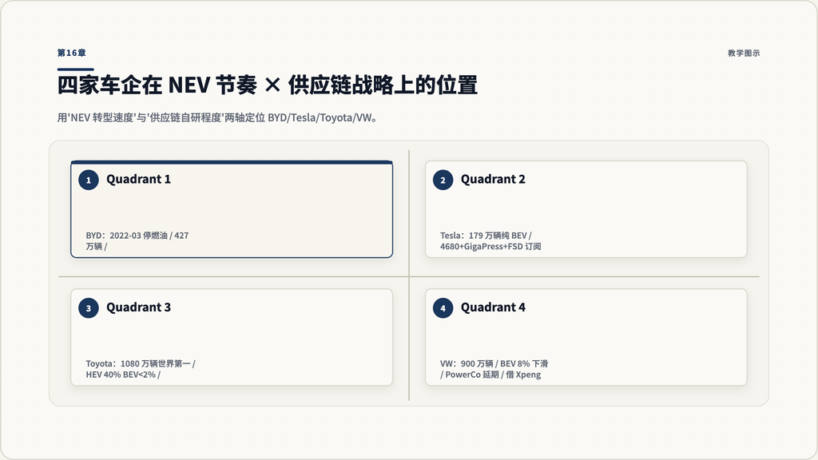

第16章：四家车企新能源转型节奏 × 供应链战略

### 16.1 为什么要做这场对比

第 1 章里我说过一句话：“比亚迪不是’卖得便宜的特斯拉’，是一家完全不同物种的公司。”这一章把这句话拆开来证明。

把四家全球最重要的车企放在同一张表上看，会发现一件反常识的事：**他们走的不是四条略有差异的路，是四条根本不同的战略**。理解这件事，是理解 2025-2030 全球汽车格局的钥匙。

四家公司选的样本不是随机的：

- **比亚迪**：垂直一体化代表，所有零件自己做。
- **特斯拉**：软件定义代表，所有体验自己控制。
- **丰田**：多路径代表，所有技术都押一点。
- **大众**：传统燃油转型代表，被迫从旧船跳到新船。

每一家都是各自路径上的世界第一。把四家叠加起来，几乎可以覆盖”汽车产业怎么过渡到电动化”的全部可能性。

### 16.2 四公司四维度

四个维度分别是：

- **维度 1 — 销量与 NEV 节奏**：体量多大、NEV 占比多少、转型从哪一年开始。
- **维度 2 — 技术路径选择**：BEV 单一 vs 多路径 vs 全栈自研。
- **维度 3 — 供应链战略**：垂直一体化、关键件自研、外采为主、还是联盟体系。
- **维度 4 — 中国市场态势**：本土领跑、独立运营、节奏掉队、还是被迫求援。

### 16.3 比亚迪：垂直一体化 + 100% NEV

回顾本教程前面 15 章已经讲清楚的内容：

- **规模**：2024 全球 4,272,145 辆（NEV 100%），首次按生产口径超过特斯拉，营收 $107B 超 Tesla $97.7B。
- **NEV 节奏**：2022-03 停止纯燃油，**全球第一家大型 OEM 这么做**。NEV 比例从 0 到 100% 仅用 14 年。
- **技术路径**：BEV + PHEV 双轨，不押单一技术。DM-i 让插混成主流。
- **供应链战略**：**关键件全部自研** — 刀片电池、30000 rpm 电机、DiPilot 智驾、IGBT 芯片、CTB 车身、4000+ 兆瓦闪充桩。**唯一在矿端也下注的车企**（已收购阿根廷、智利锂矿资源）。
- **中国市场**：本土绝对领跑，每 5 辆新车里有 1 辆是 BYD。

### 16.4 特斯拉：软件定义 + 4680 + Gigafactory 全球网

特斯拉的体量已经不是亮点（被 BYD 超过），但它在两件事上仍然是全球第一：**软件定义汽车 + 集中产能 + FSD**。

### 16.5 丰田：多路径 + 混动统治 + BEV 严重掉队

丰田是这四家里”最不像新能源公司”的一家，但它仍然是全球销量第一。这本身就值得理解。

### 16.7 一张表把四家放在一起

[output not shown]

### 16.8 学习者最容易看错的两件事

**第一**：不要把”NEV 占比 100%“当成判断指标。

特斯拉和比亚迪都是 100% NEV，但意义完全不同：

- 特斯拉是”出生就是 BEV，没经历过转型”。
- 比亚迪是”主动把自己从燃油车切换到 100% NEV”——这是一次真正的转型动作。

丰田 40% NEV 听起来很高，但其中绝大多数是 HEV（油电混动），**真正的 BEV 不到 2%**。在 2026 年的语境下，HEV 越来越接近”传统燃油车”，**它不是真正的电动化**。

大众 8% BEV 听起来低，但其中 ID 系列已经是欧洲 BEV 市占率第一。问题不是占比，是**增长曲线在 2024 出现下滑**——这是真正危险的信号。

**第二**：不要把”供应链自研程度”当成线性优劣。

四种供应链战略对应四种公司基因：

- **比亚迪垂直一体化**：成本最优、协同最强，但 capex 重、扩张慢。
- **特斯拉部分一体化 + 软件赚钱**：单车毛利最高、估值最高，但供应链脆弱（依赖宁德时代 + 比亚迪供 LFP）。
- **丰田 Keiretsu 联盟**：长期稳定、议价权强，但转型时船大难掉头。
- **大众高度外采 + 找中国求援**：短期灵活、长期没护城河，**正在被迫支付”反向技术费”**。

判断哪种战略好，要看接下来 5-10 年的环境：如果原材料价格波动、地缘冲突频繁，垂直一体化赢；如果智驾和软件成为主战场，软件定义赢；如果固态电池突破，丰田反扑；如果中国电动技术全面外溢，大众这条路才不算输得最惨。

### 16.9 一个被忽视的细节：四家都把工厂建在了哪里

如果你只关心一组数字，看四家车企的”海外工厂分布”，会发现一个奇怪的模式：

- **比亚迪**：泰国 + 巴西 + 匈牙利 + 土耳其（新兴市场为主）。
- **特斯拉**：上海 + 柏林 + 德州 + 墨西哥（推迟）（成熟市场为主）。
- **丰田**：北美 + 东南亚 + 欧洲 + 印度（全球均匀布局）。
- **大众**：欧洲 + 中国 + 北美（**正在关闭欧洲老厂**）。

这四种分布对应四种世界观：BYD 押新兴市场增长、Tesla 押成熟市场利润、丰田押全球均衡、大众押欧洲 + 中国但都在被夹击。

**告诉你一个公司怎么布工厂，等于告诉你这家公司对未来 20 年世界的判断**。

### 16.10 把这张表反向用一次

- 它的体量 vs NEV 占比，跟哪一家最像？
- 它的供应链战略，是”自研 + 一体化”，还是”软件赚钱”，还是”联盟稳定”，还是”高度外采”？
- 它有没有”自己的固态电池等价物”——一项 5-10 年后才能验证的长期押注？
- 它在中国市场是领跑、独立运营、节奏掉队、还是被迫求援？
- 它的海外工厂分布暴露了它对未来 20 年的什么判断？

写下来。如果一家公司的答案在四个维度里都”什么都像、什么都不像”，要么它有第五种独特模式，要么它的战略还没真正成型。

### 16.11 这一章的关键检查点

- 不要把”NEV 100%“当成统一判断标准——特斯拉和 BYD 走的是完全不同的路。
- 丰田的 40% NEV 大部分是 HEV，不是真正的电动化。
- 大众正在向中国合作伙伴付”反向技术费”，这是德系汽车 60 年来第一次。
- 四种供应链战略各有禀赋，没有最优解，只有”匹配你的禀赋”。
- 看一家车企的海外工厂分布，就能看出它对未来 20 年世界的判断。

## 参考资料

以下是本教程依赖的公开资料（精选）：

- 比亚迪官方刀片电池介绍：[BYD’s revolutionary Blade Battery](https://www.byd.com/eu/blog/BYDs-revolutionary-Blade-Battery-all-you-need-to-know)
- 比亚迪官方超级 e 平台发布：[BYD Super e-Platform with Megawatt Flash Charging](https://www.byd.com/en/news-list/BYD-Unveils-Super-e-Platform-Megawatt-Flash-Charging-Electric-Vehicles-Matching-Refueling-Speeds.html)
- 比亚迪停产纯燃油官方公告：[BYD Discontinues Gas-only Auto Line](https://en.byd.com/news/byd-discontinues-gas-only-auto-line-to-focus-on-phev-and-pure-electric-tech/)
- 仰望 U8/U9 发布：[BYD Debuted Yangwang U8 and U9](https://www.byd.com/us/news-list/BYD-Debuted-First-Luxury-Off-road-SUV-U8-All-electric-Supercar-U9-Under-Premium-Brand-Yangwang)
- 2024 全年销量：[Carnewschina: BYD sold 4.3M vehicles in 2024](https://carnewschina.com/2025/01/01/byd-sold-record-breaking-4-3-million-vehicles-in-2024-a-41-increase-from-2023/)
- 2024 营收超 Tesla：[CNN: BYD passes Tesla 2024 revenue](https://www.cnn.com/2025/03/25/cars/china-byd-annual-sales-pass-tesla-intl-hnk)
- 巴菲特彻底退出：[CNN: Berkshire fully exits BYD after 17 years](https://www.cnn.com/2025/09/22/investing/warren-buffet-berkshire-hathaway-exits-byd)
- DM-i 5.0 发布：[CnEVPost: BYD launches 5th-gen DM tech](https://cnevpost.com/2024/05/28/byd-launches-5th-gen-dm-tech/)
- DM-i 5.0 油耗 OTA 优化：[CnEVPost: BYD reduces DM-i fuel consumption](https://cnevpost.com/2025/08/05/byd-reduces-fuel-consumption-dm-hybrid-tech/)
- 1000V 超级 e 平台细节：[Electrek: BYD 1000V Super e-Platform](https://electrek.co/2025/03/17/byd-confirms-1000v-super-e-platform-fast-charging-400km-5-minutes/)
- 1MW 闪充站铺设：[CnEVPost: First 1000-kW charging stations](https://cnevpost.com/2025/03/26/byd-1st-1000-kw-charging-stations-ready-apr/)
- 戴姆勒退出腾势：[CnEVPost: BYD takes 100% of Denza](https://cnevpost.com/2024/09/16/byd-holds-100-pct-denza/)
- 仰望 U9 上市：[CnEVPost: Yangwang U9 supercar launch](https://cnevpost.com/2024/02/25/byd-yangwang-launches-u9-electric-supercar/)
- 天神之眼系统：[Carnewschina: BYD God’s Eye release](https://carnewschina.com/2025/02/10/byd-released-the-new-gods-eye-driving-assistance-system/)
- 海外工厂概览：[Rho Motion: BYD global expansion](https://rhomotion.com/news/byd-announces-further-global-expansion-industry-update/)
- 比亚迪 2030 海外 50% 目标：[EV.com: BYD targets 50% overseas by 2030](https://ev.com/news/byd-targets-50-percent-overseas-sales-2030)
- 比亚迪综合历史：[Wikipedia: BYD Company](https://en.wikipedia.org/wiki/BYD_Company)
- 王传福背景：[Wikipedia: Wang Chuanfu](https://en.wikipedia.org/wiki/Wang_Chuanfu)
- 刀片电池技术细节：[Wikipedia: BYD Blade battery](https://en.wikipedia.org/wiki/BYD_Blade_battery)

如果你想继续深入，可以从两个方向延伸：

1. **比较学习**：把比亚迪 vs 特斯拉 vs 丰田 vs 大众做横向对比，重点关注新能源转型节奏和供应链战略。
2. **深度案例**：单独深读”刀片电池如何重塑全球 LFP 市场”、“DM-i 5.0 技术拆解”、“匈牙利工厂与欧盟反补贴关税博弈”、“巴菲特 17 年持仓复盘”——任何一个都可以单独写成深度报告。